# Risk Factor Analysis

## Outcome Variable

**Outcome Variable:** stunted

## Predictor Variables

**Intervention Variable:** lag_WHZ_quart

**Adjustment Set:**

- arm
- sex
- W_mage
- meducyrs
- feducyrs
- single
- month
- brthmon
- delta_W_mage
- delta_meducyrs
- delta_feducyrs
- delta_single
- delta_month
- delta_brthmon

## Stratifying Variables

The analysis was stratified on these variable(s):

- agecat
- studyid
- country

## Data Summary

| agecat | studyid | country | lag_WHZ_quart | stunted | n_cell | n |
| --- | --- | --- | --- | --- | --- | --- |
| 12 months | ki0047075b-MAL-ED | BANGLADESH | 1 | 0 | 12 | 230 |
| 12 months | ki0047075b-MAL-ED | BANGLADESH | 1 | 1 | 14 | 230 |
| 12 months | ki0047075b-MAL-ED | BANGLADESH | 2 | 0 | 56 | 230 |
| 12 months | ki0047075b-MAL-ED | BANGLADESH | 2 | 1 | 35 | 230 |
| 12 months | ki0047075b-MAL-ED | BANGLADESH | 3 | 0 | 63 | 230 |
| 12 months | ki0047075b-MAL-ED | BANGLADESH | 3 | 1 | 26 | 230 |
| 12 months | ki0047075b-MAL-ED | BANGLADESH | 4 | 0 | 21 | 230 |
| 12 months | ki0047075b-MAL-ED | BANGLADESH | 4 | 1 | 3 | 230 |
| 12 months | ki0047075b-MAL-ED | BRAZIL | 1 | 0 | 24 | 194 |
| 12 months | ki0047075b-MAL-ED | BRAZIL | 1 | 1 | 1 | 194 |
| 12 months | ki0047075b-MAL-ED | BRAZIL | 2 | 0 | 59 | 194 |
| 12 months | ki0047075b-MAL-ED | BRAZIL | 2 | 1 | 3 | 194 |
| 12 months | ki0047075b-MAL-ED | BRAZIL | 3 | 0 | 75 | 194 |
| 12 months | ki0047075b-MAL-ED | BRAZIL | 3 | 1 | 3 | 194 |
| 12 months | ki0047075b-MAL-ED | BRAZIL | 4 | 0 | 28 | 194 |
| 12 months | ki0047075b-MAL-ED | BRAZIL | 4 | 1 | 1 | 194 |
| 12 months | ki0047075b-MAL-ED | INDIA | 1 | 0 | 85 | 228 |
| 12 months | ki0047075b-MAL-ED | INDIA | 1 | 1 | 50 | 228 |
| 12 months | ki0047075b-MAL-ED | INDIA | 2 | 0 | 51 | 228 |
| 12 months | ki0047075b-MAL-ED | INDIA | 2 | 1 | 16 | 228 |
| 12 months | ki0047075b-MAL-ED | INDIA | 3 | 0 | 15 | 228 |
| 12 months | ki0047075b-MAL-ED | INDIA | 3 | 1 | 5 | 228 |
| 12 months | ki0047075b-MAL-ED | INDIA | 4 | 0 | 5 | 228 |
| 12 months | ki0047075b-MAL-ED | INDIA | 4 | 1 | 1 | 228 |
| 12 months | ki0047075b-MAL-ED | NEPAL | 1 | 0 | 62 | 231 |
| 12 months | ki0047075b-MAL-ED | NEPAL | 1 | 1 | 8 | 231 |
| 12 months | ki0047075b-MAL-ED | NEPAL | 2 | 0 | 81 | 231 |
| 12 months | ki0047075b-MAL-ED | NEPAL | 2 | 1 | 11 | 231 |
| 12 months | ki0047075b-MAL-ED | NEPAL | 3 | 0 | 54 | 231 |
| 12 months | ki0047075b-MAL-ED | NEPAL | 3 | 1 | 4 | 231 |

[output cut: 874 more lines]

The following strata were considered:

- agecat: 12 months, studyid: ki0047075b-MAL-ED, country: BANGLADESH
- agecat: 12 months, studyid: ki0047075b-MAL-ED, country: BRAZIL
- agecat: 12 months, studyid: ki0047075b-MAL-ED, country: INDIA
- agecat: 12 months, studyid: ki0047075b-MAL-ED, country: NEPAL
- agecat: 12 months, studyid: ki0047075b-MAL-ED, country: PERU
- agecat: 12 months, studyid: ki0047075b-MAL-ED, country: SOUTH AFRICA
- agecat: 12 months, studyid: ki0047075b-MAL-ED, country: TANZANIA, UNITED REPUBLIC OF
- agecat: 12 months, studyid: ki1000108-CMC-V-BCS-2002, country: INDIA
- agecat: 12 months, studyid: ki1000108-IRC, country: INDIA
- agecat: 12 months, studyid: ki1000109-EE, country: PAKISTAN
- agecat: 12 months, studyid: ki1017093b-PROVIDE, country: BANGLADESH
- agecat: 12 months, studyid: ki1066203-TanzaniaChild2, country: TANZANIA, UNITED REPUBLIC OF
- agecat: 12 months, studyid: ki1101329-Keneba, country: GAMBIA
- agecat: 12 months, studyid: ki1112895-Guatemala BSC, country: GUATEMALA
- agecat: 12 months, studyid: ki1113344-GMS-Nepal, country: NEPAL
- agecat: 12 months, studyid: ki1114097-CMIN, country: BANGLADESH
- agecat: 12 months, studyid: ki1114097-CMIN, country: PERU
- agecat: 15 months, studyid: ki0047075b-MAL-ED, country: BANGLADESH
- agecat: 15 months, studyid: ki0047075b-MAL-ED, country: BRAZIL
- agecat: 15 months, studyid: ki0047075b-MAL-ED, country: INDIA
- agecat: 15 months, studyid: ki0047075b-MAL-ED, country: NEPAL
- agecat: 15 months, studyid: ki0047075b-MAL-ED, country: PERU
- agecat: 15 months, studyid: ki0047075b-MAL-ED, country: SOUTH AFRICA
- agecat: 15 months, studyid: ki0047075b-MAL-ED, country: TANZANIA, UNITED REPUBLIC OF
- agecat: 15 months, studyid: ki1000108-CMC-V-BCS-2002, country: INDIA
- agecat: 15 months, studyid: ki1000108-IRC, country: INDIA
- agecat: 15 months, studyid: ki1000109-EE, country: PAKISTAN
- agecat: 15 months, studyid: ki1017093b-PROVIDE, country: BANGLADESH
- agecat: 15 months, studyid: ki1066203-TanzaniaChild2, country: TANZANIA, UNITED REPUBLIC OF
- agecat: 15 months, studyid: ki1101329-Keneba, country: GAMBIA
- agecat: 15 months, studyid: ki1112895-Guatemala BSC, country: GUATEMALA
- agecat: 15 months, studyid: ki1113344-GMS-Nepal, country: NEPAL
- agecat: 15 months, studyid: ki1114097-CMIN, country: BANGLADESH
- agecat: 15 months, studyid: ki1114097-CMIN, country: PERU
- agecat: 18 months, studyid: ki0047075b-MAL-ED, country: BANGLADESH
- agecat: 18 months, studyid: ki0047075b-MAL-ED, country: BRAZIL
- agecat: 18 months, studyid: ki0047075b-MAL-ED, country: INDIA
- agecat: 18 months, studyid: ki0047075b-MAL-ED, country: NEPAL
- agecat: 18 months, studyid: ki0047075b-MAL-ED, country: PERU
- agecat: 18 months, studyid: ki0047075b-MAL-ED, country: SOUTH AFRICA
- agecat: 18 months, studyid: ki0047075b-MAL-ED, country: TANZANIA, UNITED REPUBLIC OF
- agecat: 18 months, studyid: ki1000108-CMC-V-BCS-2002, country: INDIA
- agecat: 18 months, studyid: ki1000108-IRC, country: INDIA
- agecat: 18 months, studyid: ki1000109-EE, country: PAKISTAN
- agecat: 18 months, studyid: ki1017093b-PROVIDE, country: BANGLADESH
- agecat: 18 months, studyid: ki1066203-TanzaniaChild2, country: TANZANIA, UNITED REPUBLIC OF
- agecat: 18 months, studyid: ki1101329-Keneba, country: GAMBIA
- agecat: 18 months, studyid: ki1113344-GMS-Nepal, country: NEPAL
- agecat: 18 months, studyid: ki1114097-CMIN, country: BANGLADESH
- agecat: 18 months, studyid: ki1114097-CMIN, country: PERU
- agecat: 21 months, studyid: ki0047075b-MAL-ED, country: BANGLADESH
- agecat: 21 months, studyid: ki0047075b-MAL-ED, country: BRAZIL
- agecat: 21 months, studyid: ki0047075b-MAL-ED, country: INDIA
- agecat: 21 months, studyid: ki0047075b-MAL-ED, country: NEPAL
- agecat: 21 months, studyid: ki0047075b-MAL-ED, country: PERU
- agecat: 21 months, studyid: ki0047075b-MAL-ED, country: SOUTH AFRICA
- agecat: 21 months, studyid: ki0047075b-MAL-ED, country: TANZANIA, UNITED REPUBLIC OF
- agecat: 21 months, studyid: ki1000108-CMC-V-BCS-2002, country: INDIA
- agecat: 21 months, studyid: ki1000108-IRC, country: INDIA
- agecat: 21 months, studyid: ki1017093b-PROVIDE, country: BANGLADESH
- agecat: 21 months, studyid: ki1066203-TanzaniaChild2, country: TANZANIA, UNITED REPUBLIC OF
- agecat: 21 months, studyid: ki1101329-Keneba, country: GAMBIA
- agecat: 21 months, studyid: ki1113344-GMS-Nepal, country: NEPAL
- agecat: 21 months, studyid: ki1114097-CMIN, country: BANGLADESH
- agecat: 21 months, studyid: ki1114097-CMIN, country: PERU
- agecat: 3 months, studyid: ki0047075b-MAL-ED, country: BANGLADESH
- agecat: 3 months, studyid: ki0047075b-MAL-ED, country: BRAZIL
- agecat: 3 months, studyid: ki0047075b-MAL-ED, country: INDIA
- agecat: 3 months, studyid: ki0047075b-MAL-ED, country: NEPAL
- agecat: 3 months, studyid: ki0047075b-MAL-ED, country: PERU
- agecat: 3 months, studyid: ki0047075b-MAL-ED, country: SOUTH AFRICA
- agecat: 3 months, studyid: ki0047075b-MAL-ED, country: TANZANIA, UNITED REPUBLIC OF
- agecat: 3 months, studyid: ki1000108-CMC-V-BCS-2002, country: INDIA
- agecat: 3 months, studyid: ki1000108-IRC, country: INDIA
- agecat: 3 months, studyid: ki1000109-EE, country: PAKISTAN
- agecat: 3 months, studyid: ki1017093b-PROVIDE, country: BANGLADESH
- agecat: 3 months, studyid: ki1066203-TanzaniaChild2, country: TANZANIA, UNITED REPUBLIC OF
- agecat: 3 months, studyid: ki1101329-Keneba, country: GAMBIA
- agecat: 3 months, studyid: ki1114097-CMIN, country: BANGLADESH
- agecat: 3 months, studyid: ki1114097-CMIN, country: PERU
- agecat: 6 months, studyid: ki0047075b-MAL-ED, country: BANGLADESH
- agecat: 6 months, studyid: ki0047075b-MAL-ED, country: BRAZIL
- agecat: 6 months, studyid: ki0047075b-MAL-ED, country: INDIA
- agecat: 6 months, studyid: ki0047075b-MAL-ED, country: NEPAL
- agecat: 6 months, studyid: ki0047075b-MAL-ED, country: PERU
- agecat: 6 months, studyid: ki0047075b-MAL-ED, country: SOUTH AFRICA
- agecat: 6 months, studyid: ki0047075b-MAL-ED, country: TANZANIA, UNITED REPUBLIC OF
- agecat: 6 months, studyid: ki1000108-CMC-V-BCS-2002, country: INDIA
- agecat: 6 months, studyid: ki1000108-IRC, country: INDIA
- agecat: 6 months, studyid: ki1000109-EE, country: PAKISTAN
- agecat: 6 months, studyid: ki1017093b-PROVIDE, country: BANGLADESH
- agecat: 6 months, studyid: ki1066203-TanzaniaChild2, country: TANZANIA, UNITED REPUBLIC OF
- agecat: 6 months, studyid: ki1101329-Keneba, country: GAMBIA
- agecat: 6 months, studyid: ki1112895-Guatemala BSC, country: GUATEMALA
- agecat: 6 months, studyid: ki1114097-CMIN, country: BANGLADESH
- agecat: 6 months, studyid: ki1114097-CMIN, country: PERU
- agecat: 9 months, studyid: ki0047075b-MAL-ED, country: BANGLADESH
- agecat: 9 months, studyid: ki0047075b-MAL-ED, country: BRAZIL
- agecat: 9 months, studyid: ki0047075b-MAL-ED, country: INDIA
- agecat: 9 months, studyid: ki0047075b-MAL-ED, country: NEPAL
- agecat: 9 months, studyid: ki0047075b-MAL-ED, country: PERU
- agecat: 9 months, studyid: ki0047075b-MAL-ED, country: SOUTH AFRICA
- agecat: 9 months, studyid: ki0047075b-MAL-ED, country: TANZANIA, UNITED REPUBLIC OF
- agecat: 9 months, studyid: ki1000108-CMC-V-BCS-2002, country: INDIA
- agecat: 9 months, studyid: ki1000108-IRC, country: INDIA
- agecat: 9 months, studyid: ki1000109-EE, country: PAKISTAN
- agecat: 9 months, studyid: ki1017093b-PROVIDE, country: BANGLADESH
- agecat: 9 months, studyid: ki1066203-TanzaniaChild2, country: TANZANIA, UNITED REPUBLIC OF
- agecat: 9 months, studyid: ki1101329-Keneba, country: GAMBIA
- agecat: 9 months, studyid: ki1112895-Guatemala BSC, country: GUATEMALA
- agecat: 9 months, studyid: ki1113344-GMS-Nepal, country: NEPAL
- agecat: 9 months, studyid: ki1114097-CMIN, country: BANGLADESH
- agecat: 9 months, studyid: ki1114097-CMIN, country: PERU

### Dropped Strata

Some strata were dropped due to rare outcomes:

- agecat: 12 months, studyid: ki0047075b-MAL-ED, country: BANGLADESH
- agecat: 12 months, studyid: ki0047075b-MAL-ED, country: BRAZIL
- agecat: 12 months, studyid: ki0047075b-MAL-ED, country: INDIA
- agecat: 12 months, studyid: ki0047075b-MAL-ED, country: NEPAL
- agecat: 12 months, studyid: ki1000108-CMC-V-BCS-2002, country: INDIA
- agecat: 12 months, studyid: ki1000108-IRC, country: INDIA
- agecat: 12 months, studyid: ki1000109-EE, country: PAKISTAN
- agecat: 12 months, studyid: ki1113344-GMS-Nepal, country: NEPAL
- agecat: 15 months, studyid: ki0047075b-MAL-ED, country: BANGLADESH
- agecat: 15 months, studyid: ki0047075b-MAL-ED, country: BRAZIL
- agecat: 15 months, studyid: ki0047075b-MAL-ED, country: INDIA
- agecat: 15 months, studyid: ki0047075b-MAL-ED, country: NEPAL
- agecat: 15 months, studyid: ki1000108-CMC-V-BCS-2002, country: INDIA
- agecat: 15 months, studyid: ki1000108-IRC, country: INDIA
- agecat: 15 months, studyid: ki1000109-EE, country: PAKISTAN
- agecat: 15 months, studyid: ki1112895-Guatemala BSC, country: GUATEMALA
- agecat: 15 months, studyid: ki1113344-GMS-Nepal, country: NEPAL
- agecat: 18 months, studyid: ki0047075b-MAL-ED, country: BANGLADESH
- agecat: 18 months, studyid: ki0047075b-MAL-ED, country: BRAZIL
- agecat: 18 months, studyid: ki0047075b-MAL-ED, country: INDIA
- agecat: 18 months, studyid: ki0047075b-MAL-ED, country: NEPAL
- agecat: 18 months, studyid: ki0047075b-MAL-ED, country: TANZANIA, UNITED REPUBLIC OF
- agecat: 18 months, studyid: ki1000108-CMC-V-BCS-2002, country: INDIA
- agecat: 18 months, studyid: ki1000108-IRC, country: INDIA
- agecat: 18 months, studyid: ki1000109-EE, country: PAKISTAN
- agecat: 18 months, studyid: ki1113344-GMS-Nepal, country: NEPAL
- agecat: 18 months, studyid: ki1114097-CMIN, country: PERU
- agecat: 21 months, studyid: ki0047075b-MAL-ED, country: BANGLADESH
- agecat: 21 months, studyid: ki0047075b-MAL-ED, country: BRAZIL
- agecat: 21 months, studyid: ki0047075b-MAL-ED, country: INDIA
- agecat: 21 months, studyid: ki0047075b-MAL-ED, country: NEPAL
- agecat: 21 months, studyid: ki1000108-CMC-V-BCS-2002, country: INDIA
- agecat: 21 months, studyid: ki1000108-IRC, country: INDIA
- agecat: 21 months, studyid: ki1066203-TanzaniaChild2, country: TANZANIA, UNITED REPUBLIC OF
- agecat: 21 months, studyid: ki1113344-GMS-Nepal, country: NEPAL
- agecat: 21 months, studyid: ki1114097-CMIN, country: PERU
- agecat: 3 months, studyid: ki0047075b-MAL-ED, country: BANGLADESH
- agecat: 3 months, studyid: ki0047075b-MAL-ED, country: BRAZIL
- agecat: 3 months, studyid: ki0047075b-MAL-ED, country: INDIA
- agecat: 3 months, studyid: ki0047075b-MAL-ED, country: NEPAL
- agecat: 3 months, studyid: ki0047075b-MAL-ED, country: SOUTH AFRICA
- agecat: 3 months, studyid: ki0047075b-MAL-ED, country: TANZANIA, UNITED REPUBLIC OF
- agecat: 3 months, studyid: ki1000108-CMC-V-BCS-2002, country: INDIA
- agecat: 3 months, studyid: ki1000108-IRC, country: INDIA
- agecat: 3 months, studyid: ki1000109-EE, country: PAKISTAN
- agecat: 6 months, studyid: ki0047075b-MAL-ED, country: BANGLADESH
- agecat: 6 months, studyid: ki0047075b-MAL-ED, country: BRAZIL
- agecat: 6 months, studyid: ki0047075b-MAL-ED, country: INDIA
- agecat: 6 months, studyid: ki0047075b-MAL-ED, country: NEPAL
- agecat: 6 months, studyid: ki1000108-CMC-V-BCS-2002, country: INDIA
- agecat: 6 months, studyid: ki1000108-IRC, country: INDIA
- agecat: 6 months, studyid: ki1000109-EE, country: PAKISTAN
- agecat: 6 months, studyid: ki1017093b-PROVIDE, country: BANGLADESH
- agecat: 6 months, studyid: ki1114097-CMIN, country: PERU
- agecat: 9 months, studyid: ki0047075b-MAL-ED, country: BANGLADESH
- agecat: 9 months, studyid: ki0047075b-MAL-ED, country: BRAZIL
- agecat: 9 months, studyid: ki0047075b-MAL-ED, country: INDIA
- agecat: 9 months, studyid: ki0047075b-MAL-ED, country: NEPAL
- agecat: 9 months, studyid: ki1000108-CMC-V-BCS-2002, country: INDIA
- agecat: 9 months, studyid: ki1000108-IRC, country: INDIA
- agecat: 9 months, studyid: ki1000109-EE, country: PAKISTAN
- agecat: 9 months, studyid: ki1113344-GMS-Nepal, country: NEPAL

## Methods Detail

We’re interested in the causal parameters $E[Y_a]$ for all values of $a \in \mathcal{A}$. These parameters represent the mean outcome if, possibly contrary to fact, we intervened to set all units to have $A=a$. Under the randomization and positivity assumptions, these are identified by the statistical parameters $\psi_a=E_W[E_{Y|A,W}(Y|A=a,W)]$. In addition, we’re interested in the mean of $Y$, $E[Y]$ under no intervention (the observed mean). We will estimate these parameters by using SuperLearner to fit the relevant likelihood factors – $E_{Y|A,W}(Y|A=a,W)$ and $p(A=a|W)$, and then updating our likelihood fit using a joint TMLE.

For unadjusted analyses ($W=\{\}$), initial likelihoods were estimated using Lrnr_glm to estimate the simple $E(Y|A)$ and Lrnr_mean to estimate $p(A)$. For adjusted analyses, a small library containing Lrnr_glmnet, Lrnr_xgboost, and Lrnr_mean was used.

Having estimated these parameters, we will then use the delta method to estimate relative risks and attributable risks relative to a prespecified baseline level of $A$.

# Results Detail

## Results Plots

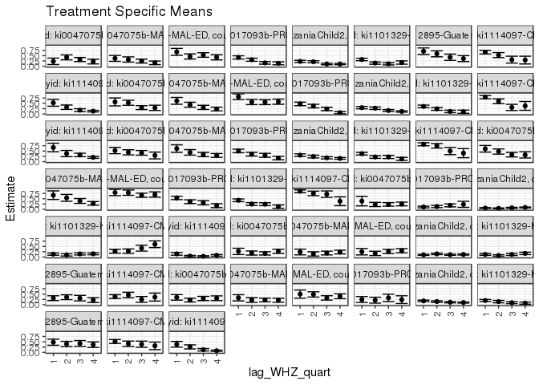

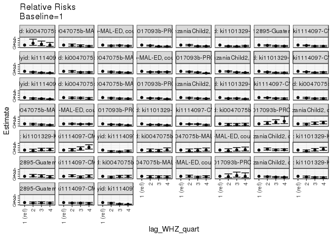

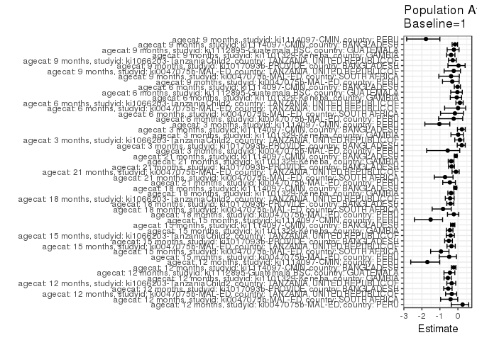

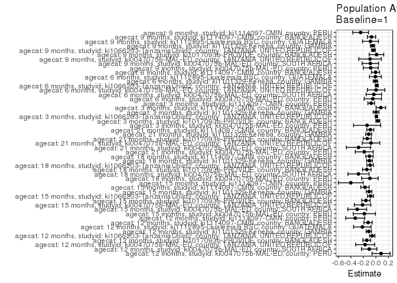

## Results Table

### Parameter: TSM

| agecat | studyid | country | intervention_level | baseline_level | estimate | ci_lower | ci_upper |
| --- | --- | --- | --- | --- | --- | --- | --- |
| 12 months | ki0047075b-MAL-ED | PERU | 1 | NA | 0.2333333 | 0.0816734 | 0.3849933 |
| 12 months | ki0047075b-MAL-ED | PERU | 2 | NA | 0.4202899 | 0.3035833 | 0.5369964 |
| 12 months | ki0047075b-MAL-ED | PERU | 3 | NA | 0.3186813 | 0.2227473 | 0.4146153 |
| 12 months | ki0047075b-MAL-ED | PERU | 4 | NA | 0.2222222 | 0.1111093 | 0.3333351 |
| 12 months | ki0047075b-MAL-ED | SOUTH AFRICA | 1 | NA | 0.3711935 | 0.2318344 | 0.5105526 |
| 12 months | ki0047075b-MAL-ED | SOUTH AFRICA | 2 | NA | 0.3193722 | 0.1961988 | 0.4425455 |
| 12 months | ki0047075b-MAL-ED | SOUTH AFRICA | 3 | NA | 0.2447974 | 0.1529937 | 0.3366010 |
| 12 months | ki0047075b-MAL-ED | SOUTH AFRICA | 4 | NA | 0.1620871 | 0.0789668 | 0.2452074 |
| 12 months | ki0047075b-MAL-ED | TANZANIA, UNITED REPUBLIC OF | 1 | NA | 0.6790204 | 0.5173265 | 0.8407142 |
| 12 months | ki0047075b-MAL-ED | TANZANIA, UNITED REPUBLIC OF | 2 | NA | 0.4619044 | 0.3408678 | 0.5829411 |
| 12 months | ki0047075b-MAL-ED | TANZANIA, UNITED REPUBLIC OF | 3 | NA | 0.5328004 | 0.4259687 | 0.6396322 |
| 12 months | ki0047075b-MAL-ED | TANZANIA, UNITED REPUBLIC OF | 4 | NA | 0.4218406 | 0.3009621 | 0.5427191 |
| 12 months | ki1017093b-PROVIDE | BANGLADESH | 1 | NA | 0.4174093 | 0.3408024 | 0.4940161 |
| 12 months | ki1017093b-PROVIDE | BANGLADESH | 2 | NA | 0.3091694 | 0.2369213 | 0.3814176 |
| 12 months | ki1017093b-PROVIDE | BANGLADESH | 3 | NA | 0.1588599 | 0.0992164 | 0.2185034 |
| 12 months | ki1017093b-PROVIDE | BANGLADESH | 4 | NA | 0.1386281 | 0.0698590 | 0.2073971 |
| 12 months | ki1066203-TanzaniaChild2 | TANZANIA, UNITED REPUBLIC OF | 1 | NA | 0.2306454 | 0.1806387 | 0.2806520 |
| 12 months | ki1066203-TanzaniaChild2 | TANZANIA, UNITED REPUBLIC OF | 2 | NA | 0.2136959 | 0.1657014 | 0.2616904 |
| 12 months | ki1066203-TanzaniaChild2 | TANZANIA, UNITED REPUBLIC OF | 3 | NA | 0.1083347 | 0.0720931 | 0.1445763 |
| 12 months | ki1066203-TanzaniaChild2 | TANZANIA, UNITED REPUBLIC OF | 4 | NA | 0.1065561 | 0.0769096 | 0.1362026 |
| 12 months | ki1101329-Keneba | GAMBIA | 1 | NA | 0.3199143 | 0.2614306 | 0.3783980 |
| 12 months | ki1101329-Keneba | GAMBIA | 2 | NA | 0.1506277 | 0.0969467 | 0.2043088 |
| 12 months | ki1101329-Keneba | GAMBIA | 3 | NA | 0.1171881 | 0.0642745 | 0.1701018 |
| 12 months | ki1101329-Keneba | GAMBIA | 4 | NA | 0.1759706 | 0.0976494 | 0.2542919 |
| 12 months | ki1112895-Guatemala BSC | GUATEMALA | 1 | NA | 0.7107283 | 0.5579330 | 0.8635235 |
| 12 months | ki1112895-Guatemala BSC | GUATEMALA | 2 | NA | 0.5880867 | 0.4474811 | 0.7286922 |
| 12 months | ki1112895-Guatemala BSC | GUATEMALA | 3 | NA | 0.4257512 | 0.2787399 | 0.5727625 |
| 12 months | ki1112895-Guatemala BSC | GUATEMALA | 4 | NA | 0.3607338 | 0.2203189 | 0.5011487 |
| 12 months | ki1114097-CMIN | BANGLADESH | 1 | NA | 0.6666667 | 0.5799513 | 0.7533820 |
| 12 months | ki1114097-CMIN | BANGLADESH | 2 | NA | 0.5285714 | 0.4113882 | 0.6457547 |

[output cut: 174 more lines]

### Parameter: E(Y)

| agecat | studyid | country | intervention_level | baseline_level | estimate | ci_lower | ci_upper |
| --- | --- | --- | --- | --- | --- | --- | --- |
| 12 months | ki0047075b-MAL-ED | PERU | NA | NA | 0.3155738 | 0.2571407 | 0.3740068 |
| 12 months | ki0047075b-MAL-ED | SOUTH AFRICA | NA | NA | 0.2640000 | 0.2092493 | 0.3187507 |
| 12 months | ki0047075b-MAL-ED | TANZANIA, UNITED REPUBLIC OF | NA | NA | 0.5064935 | 0.4418809 | 0.5711062 |
| 12 months | ki1017093b-PROVIDE | BANGLADESH | NA | NA | 0.2714026 | 0.2341712 | 0.3086339 |
| 12 months | ki1066203-TanzaniaChild2 | TANZANIA, UNITED REPUBLIC OF | NA | NA | 0.1714507 | 0.1508672 | 0.1920342 |
| 12 months | ki1101329-Keneba | GAMBIA | NA | NA | 0.2055921 | 0.1734423 | 0.2377419 |
| 12 months | ki1112895-Guatemala BSC | GUATEMALA | NA | NA | 0.4935065 | 0.4142863 | 0.5727267 |
| 12 months | ki1114097-CMIN | BANGLADESH | NA | NA | 0.5416667 | 0.4784974 | 0.6048359 |
| 12 months | ki1114097-CMIN | PERU | NA | NA | 0.1946429 | 0.1618216 | 0.2274641 |
| 15 months | ki0047075b-MAL-ED | PERU | NA | NA | 0.3826087 | 0.3196598 | 0.4455576 |
| 15 months | ki0047075b-MAL-ED | SOUTH AFRICA | NA | NA | 0.3181818 | 0.2593772 | 0.3769865 |
| 15 months | ki0047075b-MAL-ED | TANZANIA, UNITED REPUBLIC OF | NA | NA | 0.5991379 | 0.5359400 | 0.6623359 |
| 15 months | ki1017093b-PROVIDE | BANGLADESH | NA | NA | 0.3157895 | 0.2730788 | 0.3585001 |
| 15 months | ki1066203-TanzaniaChild2 | TANZANIA, UNITED REPUBLIC OF | NA | NA | 0.2116105 | 0.1871027 | 0.2361183 |
| 15 months | ki1101329-Keneba | GAMBIA | NA | NA | 0.2456747 | 0.2105495 | 0.2808000 |
| 15 months | ki1114097-CMIN | BANGLADESH | NA | NA | 0.6176471 | 0.5557776 | 0.6795165 |
| 15 months | ki1114097-CMIN | PERU | NA | NA | 0.2651822 | 0.2262161 | 0.3041483 |
| 18 months | ki0047075b-MAL-ED | PERU | NA | NA | 0.4266055 | 0.3608006 | 0.4924104 |
| 18 months | ki0047075b-MAL-ED | SOUTH AFRICA | NA | NA | 0.3375000 | 0.2775514 | 0.3974486 |
| 18 months | ki1017093b-PROVIDE | BANGLADESH | NA | NA | 0.3574879 | 0.3112664 | 0.4037095 |
| 18 months | ki1066203-TanzaniaChild2 | TANZANIA, UNITED REPUBLIC OF | NA | NA | 0.2128655 | 0.1854121 | 0.2403189 |
| 18 months | ki1101329-Keneba | GAMBIA | NA | NA | 0.2716858 | 0.2363857 | 0.3069859 |
| 18 months | ki1114097-CMIN | BANGLADESH | NA | NA | 0.7167382 | 0.6587582 | 0.7747182 |
| 21 months | ki0047075b-MAL-ED | PERU | NA | NA | 0.4190476 | 0.3521552 | 0.4859400 |
| 21 months | ki0047075b-MAL-ED | SOUTH AFRICA | NA | NA | 0.3891213 | 0.3271801 | 0.4510625 |
| 21 months | ki0047075b-MAL-ED | TANZANIA, UNITED REPUBLIC OF | NA | NA | 0.7149533 | 0.6543278 | 0.7755787 |
| 21 months | ki1017093b-PROVIDE | BANGLADESH | NA | NA | 0.4000000 | 0.3519308 | 0.4480692 |
| 21 months | ki1101329-Keneba | GAMBIA | NA | NA | 0.3109656 | 0.2742323 | 0.3476989 |
| 21 months | ki1114097-CMIN | BANGLADESH | NA | NA | 0.7606838 | 0.7058992 | 0.8154683 |
| 3 months | ki0047075b-MAL-ED | PERU | NA | NA | 0.2482270 | 0.1977186 | 0.2987353 |
| 3 months | ki1017093b-PROVIDE | BANGLADESH | NA | NA | 0.1396934 | 0.1116252 | 0.1677615 |
| 3 months | ki1066203-TanzaniaChild2 | TANZANIA, UNITED REPUBLIC OF | NA | NA | 0.0682949 | 0.0577780 | 0.0788117 |
| 3 months | ki1101329-Keneba | GAMBIA | NA | NA | 0.1371994 | 0.1118203 | 0.1625786 |
| 3 months | ki1114097-CMIN | BANGLADESH | NA | NA | 0.3508065 | 0.2912923 | 0.4103206 |
| 3 months | ki1114097-CMIN | PERU | NA | NA | 0.0733788 | 0.0522485 | 0.0945092 |
| 6 months | ki0047075b-MAL-ED | PERU | NA | NA | 0.2148148 | 0.1657364 | 0.2638932 |
| 6 months | ki0047075b-MAL-ED | SOUTH AFRICA | NA | NA | 0.2031873 | 0.1533098 | 0.2530647 |
| 6 months | ki0047075b-MAL-ED | TANZANIA, UNITED REPUBLIC OF | NA | NA | 0.2520661 | 0.1972475 | 0.3068848 |
| 6 months | ki1066203-TanzaniaChild2 | TANZANIA, UNITED REPUBLIC OF | NA | NA | 0.1184834 | 0.1039441 | 0.1330227 |
| 6 months | ki1101329-Keneba | GAMBIA | NA | NA | 0.1149733 | 0.0920981 | 0.1378484 |
| 6 months | ki1112895-Guatemala BSC | GUATEMALA | NA | NA | 0.3004292 | 0.2414375 | 0.3594209 |
| 6 months | ki1114097-CMIN | BANGLADESH | NA | NA | 0.3765690 | 0.3150122 | 0.4381258 |
| 9 months | ki0047075b-MAL-ED | PERU | NA | NA | 0.2629482 | 0.2083772 | 0.3175192 |
| 9 months | ki0047075b-MAL-ED | SOUTH AFRICA | NA | NA | 0.2360000 | 0.1832587 | 0.2887413 |
| 9 months | ki0047075b-MAL-ED | TANZANIA, UNITED REPUBLIC OF | NA | NA | 0.4067797 | 0.3439736 | 0.4695858 |
| 9 months | ki1017093b-PROVIDE | BANGLADESH | NA | NA | 0.2521008 | 0.1737550 | 0.3304466 |
| 9 months | ki1066203-TanzaniaChild2 | TANZANIA, UNITED REPUBLIC OF | NA | NA | 0.1389728 | 0.1223021 | 0.1556435 |
| 9 months | ki1101329-Keneba | GAMBIA | NA | NA | 0.1443299 | 0.1178775 | 0.1707823 |
| 9 months | ki1112895-Guatemala BSC | GUATEMALA | NA | NA | 0.3932584 | 0.3212966 | 0.4652203 |
| 9 months | ki1114097-CMIN | BANGLADESH | NA | NA | 0.4426230 | 0.3801724 | 0.5050735 |
| 9 months | ki1114097-CMIN | PERU | NA | NA | 0.1378709 | 0.1096173 | 0.1661244 |

### Parameter: RR

| agecat | studyid | country | intervention_level | baseline_level | estimate | ci_lower | ci_upper |
| --- | --- | --- | --- | --- | --- | --- | --- |
| 12 months | ki0047075b-MAL-ED | PERU | 1 | 1 | 1.0000000 | 1.0000000 | 1.0000000 |
| 12 months | ki0047075b-MAL-ED | PERU | 2 | 1 | 1.8012422 | 0.8884067 | 3.6520140 |
| 12 months | ki0047075b-MAL-ED | PERU | 3 | 1 | 1.3657771 | 0.6672600 | 2.7955324 |
| 12 months | ki0047075b-MAL-ED | PERU | 4 | 1 | 0.9523810 | 0.4194406 | 2.1624740 |
| 12 months | ki0047075b-MAL-ED | SOUTH AFRICA | 1 | 1 | 1.0000000 | 1.0000000 | 1.0000000 |
| 12 months | ki0047075b-MAL-ED | SOUTH AFRICA | 2 | 1 | 0.8603927 | 0.5041201 | 1.4684507 |
| 12 months | ki0047075b-MAL-ED | SOUTH AFRICA | 3 | 1 | 0.6594873 | 0.3884956 | 1.1195069 |
| 12 months | ki0047075b-MAL-ED | SOUTH AFRICA | 4 | 1 | 0.4366646 | 0.2321954 | 0.8211878 |
| 12 months | ki0047075b-MAL-ED | TANZANIA, UNITED REPUBLIC OF | 1 | 1 | 1.0000000 | 1.0000000 | 1.0000000 |
| 12 months | ki0047075b-MAL-ED | TANZANIA, UNITED REPUBLIC OF | 2 | 1 | 0.6802512 | 0.4773357 | 0.9694261 |
| 12 months | ki0047075b-MAL-ED | TANZANIA, UNITED REPUBLIC OF | 3 | 1 | 0.7846604 | 0.5755416 | 1.0697611 |
| 12 months | ki0047075b-MAL-ED | TANZANIA, UNITED REPUBLIC OF | 4 | 1 | 0.6212488 | 0.4275153 | 0.9027748 |
| 12 months | ki1017093b-PROVIDE | BANGLADESH | 1 | 1 | 1.0000000 | 1.0000000 | 1.0000000 |
| 12 months | ki1017093b-PROVIDE | BANGLADESH | 2 | 1 | 0.7406865 | 0.5506138 | 0.9963726 |
| 12 months | ki1017093b-PROVIDE | BANGLADESH | 3 | 1 | 0.3805854 | 0.2505651 | 0.5780745 |
| 12 months | ki1017093b-PROVIDE | BANGLADESH | 4 | 1 | 0.3321155 | 0.1957550 | 0.5634631 |
| 12 months | ki1066203-TanzaniaChild2 | TANZANIA, UNITED REPUBLIC OF | 1 | 1 | 1.0000000 | 1.0000000 | 1.0000000 |
| 12 months | ki1066203-TanzaniaChild2 | TANZANIA, UNITED REPUBLIC OF | 2 | 1 | 0.9265128 | 0.6777517 | 1.2665788 |
| 12 months | ki1066203-TanzaniaChild2 | TANZANIA, UNITED REPUBLIC OF | 3 | 1 | 0.4697026 | 0.3153245 | 0.6996618 |
| 12 months | ki1066203-TanzaniaChild2 | TANZANIA, UNITED REPUBLIC OF | 4 | 1 | 0.4619910 | 0.3246201 | 0.6574938 |
| 12 months | ki1101329-Keneba | GAMBIA | 1 | 1 | 1.0000000 | 1.0000000 | 1.0000000 |
| 12 months | ki1101329-Keneba | GAMBIA | 2 | 1 | 0.4708378 | 0.3155583 | 0.7025272 |
| 12 months | ki1101329-Keneba | GAMBIA | 3 | 1 | 0.3663111 | 0.2251105 | 0.5960796 |
| 12 months | ki1101329-Keneba | GAMBIA | 4 | 1 | 0.5500555 | 0.3398693 | 0.8902279 |
| 12 months | ki1112895-Guatemala BSC | GUATEMALA | 1 | 1 | 1.0000000 | 1.0000000 | 1.0000000 |
| 12 months | ki1112895-Guatemala BSC | GUATEMALA | 2 | 1 | 0.8274423 | 0.6011258 | 1.1389643 |
| 12 months | ki1112895-Guatemala BSC | GUATEMALA | 3 | 1 | 0.5990352 | 0.3991278 | 0.8990682 |
| 12 months | ki1112895-Guatemala BSC | GUATEMALA | 4 | 1 | 0.5075551 | 0.3253659 | 0.7917616 |
| 12 months | ki1114097-CMIN | BANGLADESH | 1 | 1 | 1.0000000 | 1.0000000 | 1.0000000 |
| 12 months | ki1114097-CMIN | BANGLADESH | 2 | 1 | 0.7928571 | 0.6131466 | 1.0252400 |

[output cut: 174 more lines]

### Parameter: PAR

| agecat | studyid | country | intervention_level | baseline_level | estimate | ci_lower | ci_upper |
| --- | --- | --- | --- | --- | --- | --- | --- |
| 12 months | ki0047075b-MAL-ED | PERU | 1 | NA | 0.0822404 | -0.0618403 | 0.2263211 |
| 12 months | ki0047075b-MAL-ED | SOUTH AFRICA | 1 | NA | -0.1071935 | -0.2303995 | 0.0160125 |
| 12 months | ki0047075b-MAL-ED | TANZANIA, UNITED REPUBLIC OF | 1 | NA | -0.1725269 | -0.3245160 | -0.0205377 |
| 12 months | ki1017093b-PROVIDE | BANGLADESH | 1 | NA | -0.1460067 | -0.2082419 | -0.0837716 |
| 12 months | ki1066203-TanzaniaChild2 | TANZANIA, UNITED REPUBLIC OF | 1 | NA | -0.0591946 | -0.1017588 | -0.0166305 |
| 12 months | ki1101329-Keneba | GAMBIA | 1 | NA | -0.1143222 | -0.1561285 | -0.0725159 |
| 12 months | ki1112895-Guatemala BSC | GUATEMALA | 1 | NA | -0.2172218 | -0.3567203 | -0.0777233 |
| 12 months | ki1114097-CMIN | BANGLADESH | 1 | NA | -0.1250000 | -0.1910783 | -0.0589217 |
| 12 months | ki1114097-CMIN | PERU | 1 | NA | -0.3303276 | -0.4817082 | -0.1789469 |
| 15 months | ki0047075b-MAL-ED | PERU | 1 | NA | -0.1847019 | -0.3612595 | -0.0081442 |
| 15 months | ki0047075b-MAL-ED | SOUTH AFRICA | 1 | NA | -0.2989414 | -0.4492105 | -0.1486722 |
| 15 months | ki0047075b-MAL-ED | TANZANIA, UNITED REPUBLIC OF | 1 | NA | -0.2133621 | -0.3448706 | -0.0818536 |
| 15 months | ki1017093b-PROVIDE | BANGLADESH | 1 | NA | -0.1593878 | -0.2258894 | -0.0928862 |
| 15 months | ki1066203-TanzaniaChild2 | TANZANIA, UNITED REPUBLIC OF | 1 | NA | -0.0855979 | -0.1330038 | -0.0381920 |
| 15 months | ki1101329-Keneba | GAMBIA | 1 | NA | -0.1093036 | -0.1540169 | -0.0645903 |
| 15 months | ki1114097-CMIN | BANGLADESH | 1 | NA | -0.1748058 | -0.2417514 | -0.1078601 |
| 15 months | ki1114097-CMIN | PERU | 1 | NA | -0.4014845 | -0.5984313 | -0.2045376 |
| 18 months | ki0047075b-MAL-ED | PERU | 1 | NA | -0.0961218 | -0.2279513 | 0.0357078 |
| 18 months | ki0047075b-MAL-ED | SOUTH AFRICA | 1 | NA | -0.2785757 | -0.4470651 | -0.1100864 |
| 18 months | ki1017093b-PROVIDE | BANGLADESH | 1 | NA | -0.1457787 | -0.2138507 | -0.0777066 |
| 18 months | ki1066203-TanzaniaChild2 | TANZANIA, UNITED REPUBLIC OF | 1 | NA | -0.0922427 | -0.1444225 | -0.0400628 |
| 18 months | ki1101329-Keneba | GAMBIA | 1 | NA | -0.1028713 | -0.1484912 | -0.0572513 |
| 18 months | ki1114097-CMIN | BANGLADESH | 1 | NA | -0.1022273 | -0.1603896 | -0.0440651 |
| 21 months | ki0047075b-MAL-ED | PERU | 1 | NA | -0.1870801 | -0.3298246 | -0.0443356 |
| 21 months | ki0047075b-MAL-ED | SOUTH AFRICA | 1 | NA | -0.2775453 | -0.4711539 | -0.0839368 |
| 21 months | ki0047075b-MAL-ED | TANZANIA, UNITED REPUBLIC OF | 1 | NA | -0.0781502 | -0.2181317 | 0.0618314 |
| 21 months | ki1017093b-PROVIDE | BANGLADESH | 1 | NA | -0.1384918 | -0.2017771 | -0.0752065 |
| 21 months | ki1101329-Keneba | GAMBIA | 1 | NA | -0.1150147 | -0.1634047 | -0.0666247 |
| 21 months | ki1114097-CMIN | BANGLADESH | 1 | NA | -0.0901934 | -0.1459738 | -0.0344130 |
| 3 months | ki0047075b-MAL-ED | PERU | 1 | NA | -0.1406619 | -0.3573475 | 0.0760236 |
| 3 months | ki1017093b-PROVIDE | BANGLADESH | 1 | NA | 0.0303184 | -0.0009051 | 0.0615418 |
| 3 months | ki1066203-TanzaniaChild2 | TANZANIA, UNITED REPUBLIC OF | 1 | NA | 0.0077360 | -0.0092900 | 0.0247620 |
| 3 months | ki1101329-Keneba | GAMBIA | 1 | NA | 0.0022301 | -0.0439109 | 0.0483711 |
| 3 months | ki1114097-CMIN | BANGLADESH | 1 | NA | 0.0781087 | 0.0024420 | 0.1537754 |
| 3 months | ki1114097-CMIN | PERU | 1 | NA | -0.0753815 | -0.1283958 | -0.0223672 |
| 6 months | ki0047075b-MAL-ED | PERU | 1 | NA | -0.0498911 | -0.1874493 | 0.0876671 |
| 6 months | ki0047075b-MAL-ED | SOUTH AFRICA | 1 | NA | -0.0336549 | -0.1572597 | 0.0899500 |
| 6 months | ki0047075b-MAL-ED | TANZANIA, UNITED REPUBLIC OF | 1 | NA | 0.0020661 | -0.1380398 | 0.1421720 |
| 6 months | ki1066203-TanzaniaChild2 | TANZANIA, UNITED REPUBLIC OF | 1 | NA | 0.0134928 | -0.0102109 | 0.0371966 |
| 6 months | ki1101329-Keneba | GAMBIA | 1 | NA | -0.0071979 | -0.0428072 | 0.0284114 |
| 6 months | ki1112895-Guatemala BSC | GUATEMALA | 1 | NA | -0.0083782 | -0.1033838 | 0.0866274 |
| 6 months | ki1114097-CMIN | BANGLADESH | 1 | NA | -0.0060397 | -0.0699742 | 0.0578949 |
| 9 months | ki0047075b-MAL-ED | PERU | 1 | NA | -0.0825341 | -0.2008668 | 0.0357987 |
| 9 months | ki0047075b-MAL-ED | SOUTH AFRICA | 1 | NA | -0.0890000 | -0.2200169 | 0.0420169 |
| 9 months | ki0047075b-MAL-ED | TANZANIA, UNITED REPUBLIC OF | 1 | NA | -0.0934592 | -0.2736657 | 0.0867473 |
| 9 months | ki1017093b-PROVIDE | BANGLADESH | 1 | NA | 0.0088576 | -0.1070143 | 0.1247295 |
| 9 months | ki1066203-TanzaniaChild2 | TANZANIA, UNITED REPUBLIC OF | 1 | NA | -0.0399884 | -0.0700179 | -0.0099589 |
| 9 months | ki1101329-Keneba | GAMBIA | 1 | NA | -0.0541995 | -0.0880695 | -0.0203295 |
| 9 months | ki1112895-Guatemala BSC | GUATEMALA | 1 | NA | -0.0871067 | -0.2144915 | 0.0402781 |
| 9 months | ki1114097-CMIN | BANGLADESH | 1 | NA | -0.0704205 | -0.1366087 | -0.0042324 |
| 9 months | ki1114097-CMIN | PERU | 1 | NA | -0.2446302 | -0.3698103 | -0.1194502 |

### Parameter: PAF

| agecat | studyid | country | intervention_level | baseline_level | estimate | ci_lower | ci_upper |
| --- | --- | --- | --- | --- | --- | --- | --- |
| 12 months | ki0047075b-MAL-ED | PERU | 1 | NA | 0.2606061 | -0.3695278 | 0.6008088 |
| 12 months | ki0047075b-MAL-ED | SOUTH AFRICA | 1 | NA | -0.4060359 | -0.9592768 | -0.0090137 |
| 12 months | ki0047075b-MAL-ED | TANZANIA, UNITED REPUBLIC OF | 1 | NA | -0.3406300 | -0.6839617 | -0.0672978 |
| 12 months | ki1017093b-PROVIDE | BANGLADESH | 1 | NA | -0.5379711 | -0.7877707 | -0.3230751 |
| 12 months | ki1066203-TanzaniaChild2 | TANZANIA, UNITED REPUBLIC OF | 1 | NA | -0.3452574 | -0.6144986 | -0.1209161 |
| 12 months | ki1101329-Keneba | GAMBIA | 1 | NA | -0.5560631 | -0.7709160 | -0.3672767 |
| 12 months | ki1112895-Guatemala BSC | GUATEMALA | 1 | NA | -0.4401599 | -0.7720730 | -0.1704149 |
| 12 months | ki1114097-CMIN | BANGLADESH | 1 | NA | -0.2307692 | -0.3651429 | -0.1096222 |
| 12 months | ki1114097-CMIN | PERU | 1 | NA | -1.6970958 | -2.6196558 | -1.0096733 |
| 15 months | ki0047075b-MAL-ED | PERU | 1 | NA | -0.4827435 | -1.0343145 | -0.0807219 |
| 15 months | ki0047075b-MAL-ED | SOUTH AFRICA | 1 | NA | -0.9395300 | -1.5142876 | -0.4961600 |
| 15 months | ki0047075b-MAL-ED | TANZANIA, UNITED REPUBLIC OF | 1 | NA | -0.3561151 | -0.6057062 | -0.1453205 |
| 15 months | ki1017093b-PROVIDE | BANGLADESH | 1 | NA | -0.5047281 | -0.7356725 | -0.3045127 |
| 15 months | ki1066203-TanzaniaChild2 | TANZANIA, UNITED REPUBLIC OF | 1 | NA | -0.4045069 | -0.6460383 | -0.1984166 |
| 15 months | ki1101329-Keneba | GAMBIA | 1 | NA | -0.4449119 | -0.6381306 | -0.2744835 |
| 15 months | ki1114097-CMIN | BANGLADESH | 1 | NA | -0.2830189 | -0.4082404 | -0.1689321 |
| 15 months | ki1114097-CMIN | PERU | 1 | NA | -1.5139949 | -2.4140463 | -0.8512258 |
| 18 months | ki0047075b-MAL-ED | PERU | 1 | NA | -0.2253177 | -0.5788641 | 0.0490610 |
| 18 months | ki0047075b-MAL-ED | SOUTH AFRICA | 1 | NA | -0.8254096 | -1.4302609 | -0.3710956 |
| 18 months | ki1017093b-PROVIDE | BANGLADESH | 1 | NA | -0.4077863 | -0.6168023 | -0.2257912 |
| 18 months | ki1066203-TanzaniaChild2 | TANZANIA, UNITED REPUBLIC OF | 1 | NA | -0.4333379 | -0.6993048 | -0.2089988 |
| 18 months | ki1101329-Keneba | GAMBIA | 1 | NA | -0.3786407 | -0.5572950 | -0.2204818 |
| 18 months | ki1114097-CMIN | BANGLADESH | 1 | NA | -0.1426285 | -0.2308492 | -0.0607311 |
| 21 months | ki0047075b-MAL-ED | PERU | 1 | NA | -0.4464411 | -0.8414095 | -0.1361904 |
| 21 months | ki0047075b-MAL-ED | SOUTH AFRICA | 1 | NA | -0.7132616 | -1.3108618 | -0.2702038 |
| 21 months | ki0047075b-MAL-ED | TANZANIA, UNITED REPUBLIC OF | 1 | NA | -0.1093081 | -0.3246330 | 0.0710148 |
| 21 months | ki1017093b-PROVIDE | BANGLADESH | 1 | NA | -0.3462295 | -0.5196614 | -0.1925907 |
| 21 months | ki1101329-Keneba | GAMBIA | 1 | NA | -0.3698630 | -0.5363361 | -0.2214286 |
| 21 months | ki1114097-CMIN | BANGLADESH | 1 | NA | -0.1185689 | -0.1975391 | -0.0448063 |
| 3 months | ki0047075b-MAL-ED | PERU | 1 | NA | -0.5666667 | -1.7354880 | 0.1027398 |
| 3 months | ki1017093b-PROVIDE | BANGLADESH | 1 | NA | 0.2170351 | -0.0374059 | 0.4090701 |
| 3 months | ki1066203-TanzaniaChild2 | TANZANIA, UNITED REPUBLIC OF | 1 | NA | 0.1132739 | -0.1738922 | 0.3301912 |
| 3 months | ki1101329-Keneba | GAMBIA | 1 | NA | 0.0162545 | -0.3846753 | 0.3010959 |
| 3 months | ki1114097-CMIN | BANGLADESH | 1 | NA | 0.2226547 | -0.0252683 | 0.4106268 |
| 3 months | ki1114097-CMIN | PERU | 1 | NA | -1.0272919 | -1.8353929 | -0.4495037 |
| 6 months | ki0047075b-MAL-ED | PERU | 1 | NA | -0.2322515 | -1.0707810 | 0.2667289 |
| 6 months | ki0047075b-MAL-ED | SOUTH AFRICA | 1 | NA | -0.1656347 | -0.9634044 | 0.3079856 |
| 6 months | ki0047075b-MAL-ED | TANZANIA, UNITED REPUBLIC OF | 1 | NA | 0.0081967 | -0.7370565 | 0.4337123 |
| 6 months | ki1066203-TanzaniaChild2 | TANZANIA, UNITED REPUBLIC OF | 1 | NA | 0.1138794 | -0.1100576 | 0.2926406 |
| 6 months | ki1101329-Keneba | GAMBIA | 1 | NA | -0.0626050 | -0.4219868 | 0.2059494 |
| 6 months | ki1112895-Guatemala BSC | GUATEMALA | 1 | NA | -0.0278875 | -0.3981680 | 0.2443307 |
| 6 months | ki1114097-CMIN | BANGLADESH | 1 | NA | -0.0160386 | -0.2008355 | 0.1403198 |
| 9 months | ki0047075b-MAL-ED | PERU | 1 | NA | -0.3138795 | -0.8563387 | 0.0700622 |
| 9 months | ki0047075b-MAL-ED | SOUTH AFRICA | 1 | NA | -0.3771186 | -1.0594285 | 0.0791349 |
| 9 months | ki0047075b-MAL-ED | TANZANIA, UNITED REPUBLIC OF | 1 | NA | -0.2297538 | -0.7645292 | 0.1429473 |
| 9 months | ki1017093b-PROVIDE | BANGLADESH | 1 | NA | 0.0351351 | -0.5535584 | 0.4007536 |
| 9 months | ki1066203-TanzaniaChild2 | TANZANIA, UNITED REPUBLIC OF | 1 | NA | -0.2877428 | -0.5209700 | -0.0902788 |
| 9 months | ki1101329-Keneba | GAMBIA | 1 | NA | -0.3755252 | -0.6249241 | -0.1644049 |
| 9 months | ki1112895-Guatemala BSC | GUATEMALA | 1 | NA | -0.2214999 | -0.5968675 | 0.0656319 |
| 9 months | ki1114097-CMIN | BANGLADESH | 1 | NA | -0.1590982 | -0.3203142 | -0.0175674 |
| 9 months | ki1114097-CMIN | PERU | 1 | NA | -1.7743434 | -2.8461618 | -1.0012110 |